# Insurance Forecast by using Linear Regression

## Predicting number of insurance charges

Data: https://www.kaggle.com/mirichoi0218/insurance

```python
%pip install numpy pandas matplotlib seaborn sklearn statsmodels
```

```python
import numpy as np
import pandas as pd
import matplotlib.pyplot as plt
import seaborn as sns
%matplotlib inline
import warnings
warnings.filterwarnings('ignore')
```

```python
insurance = pd.read_csv("insurance.csv")
```

```python
insurance.shape
```

```
(1338, 7)
```

```python
insurance.info()
```

```
<class 'pandas.core.frame.DataFrame'>
RangeIndex: 1338 entries, 0 to 1337
Data columns (total 7 columns):
 #   Column    Non-Null Count  Dtype
---  ------    --------------  -----
 0   age       1338 non-null   int64
 1   sex       1338 non-null   object
 2   bmi       1338 non-null   float64
 3   children  1338 non-null   int64
 4   smoker    1338 non-null   object
 5   region    1338 non-null   object
 6   charges   1338 non-null   float64
dtypes: float64(2), int64(2), object(3)
memory usage: 73.3+ KB
```

```python
insurance.describe()
```

|  | age | bmi | children | charges |
| --- | --- | --- | --- | --- |
| count | 1338.000000 | 1338.000000 | 1338.000000 | 1338.000000 |
| mean | 39.207025 | 30.663397 | 1.094918 | 13270.422265 |
| std | 14.049960 | 6.098187 | 1.205493 | 12110.011237 |
| min | 18.000000 | 15.960000 | 0.000000 | 1121.873900 |
| 25% | 27.000000 | 26.296250 | 0.000000 | 4740.287150 |
| 50% | 39.000000 | 30.400000 | 1.000000 | 9382.033000 |
| 75% | 51.000000 | 34.693750 | 2.000000 | 16639.912515 |
| max | 64.000000 | 53.130000 | 5.000000 | 63770.428010 |

```python
insurance.head()
```

|  | age | sex | bmi | children | smoker | region | charges |
| --- | --- | --- | --- | --- | --- | --- | --- |
| 0 | 19 | female | 27.900 | 0 | yes | southwest | 16884.92400 |
| 1 | 18 | male | 33.770 | 1 | no | southeast | 1725.55230 |
| 2 | 28 | male | 33.000 | 3 | no | southeast | 4449.46200 |
| 3 | 33 | male | 22.705 | 0 | no | northwest | 21984.47061 |
| 4 | 32 | male | 28.880 | 0 | no | northwest | 3866.85520 |

Dataset has 1338 rows and 7 columns. Some fields have categorical data, others have integer/float type.

# DATA QUALITY

## Check for MISSING values

```python
# percentage of missing values in each column
round(100*(insurance.isnull().sum()/len(insurance)),2).sort_values(ascending = False)
```

```
charges     0.0
region      0.0
smoker      0.0
children    0.0
bmi         0.0
sex         0.0
age         0.0
dtype: float64
```

```python
# percentage of missing values in each row
round(100*(insurance.isnull().sum(axis=1)/len(insurance)),2).sort_values(ascending = False)
```

```
1337    0.0
439     0.0
441     0.0
442     0.0
443     0.0
       ...
892     0.0
893     0.0
894     0.0
895     0.0
0       0.0
Length: 1338, dtype: float64
```

No missing values, data is pre-sanitized

## Checking for duplicates

```python
insurance_dup=insurance.copy()
# Checking for duplicates and dropping the entire duplicate row if necessary
insurance_dup.drop_duplicates(subset=None, inplace=True)
```

```python
insurance_dup.shape
```

```
(1337, 7)
```

```python
insurance.shape
```

```
(1338, 7)
```

One duplicate row deleted

## Data Cleaning

Checking value_counts()

```python
for col in insurance:
    print(insurance[col].value_counts(ascending=True), '\n')
```

```
64    22
62    23
61    23
60    23
63    23
37    25
36    25
35    25
38    25
39    25
58    25
59    25
55    26
56    26
32    26
33    26
34    26
57    26
42    27
40    27
44    27
43    27
41    27
30    27
29    27
31    27
28    28
27    28
21    28
22    28
23    28
49    28
24    28
25    28
53    28
54    28
26    28
20    29
52    29
50    29
```

[output cut: 41 more lines]

```
southeast    364
Name: region, dtype: int64

34254.05335    1
16420.49455    1
7371.77200     1
6360.99360     1
12269.68865    1
              ..
1980.07000     1
5257.50795     1
43254.41795    1
8825.08600     1
1639.56310     2
Name: charges, Length: 1337, dtype: int64
```

No unreasonable counts/values found

## Creating Dummy Variables

Create dummies for the 4 categorical variables 'sex','children','smoker' & 'region'. Start by converting their datatype into category

```python
# Check the datatypes before convertion
insurance.info()
```

```
<class 'pandas.core.frame.DataFrame'>
RangeIndex: 1338 entries, 0 to 1337
Data columns (total 7 columns):
 #   Column    Non-Null Count  Dtype
---  ------    --------------  -----
 0   age       1338 non-null   int64
 1   sex       1338 non-null   object
 2   bmi       1338 non-null   float64
 3   children  1338 non-null   int64
 4   smoker    1338 non-null   object
 5   region    1338 non-null   object
 6   charges   1338 non-null   float64
dtypes: float64(2), int64(2), object(3)
memory usage: 73.3+ KB
```

```python
# Convert to 'category' data type

insurance['sex']=insurance['sex'].astype('category')
insurance['smoker']=insurance['smoker'].astype('category')
insurance['children']=insurance['children'].astype('category')
insurance['region']=insurance['region'].astype('category')
```

```python
insurance.info()
```

```
<class 'pandas.core.frame.DataFrame'>
RangeIndex: 1338 entries, 0 to 1337
Data columns (total 7 columns):
 #   Column    Non-Null Count  Dtype
---  ------    --------------  -----
 0   age       1338 non-null   int64
 1   sex       1338 non-null   category
 2   bmi       1338 non-null   float64
 3   children  1338 non-null   category
 4   smoker    1338 non-null   category
 5   region    1338 non-null   category
 6   charges   1338 non-null   float64
dtypes: category(4), float64(2), int64(1)
memory usage: 37.3 KB
```

```python
# Create dummies, drop original variable, drop first dummy variable for each set to avoid multicollinearity problem

insurance_new = pd.get_dummies(insurance, drop_first=True)
insurance_new.info()
```

```
<class 'pandas.core.frame.DataFrame'>
RangeIndex: 1338 entries, 0 to 1337
Data columns (total 13 columns):
 #   Column            Non-Null Count  Dtype
---  ------            --------------  -----
 0   age               1338 non-null   int64
 1   bmi               1338 non-null   float64
 2   charges           1338 non-null   float64
 3   sex_male          1338 non-null   uint8
 4   children_1        1338 non-null   uint8
 5   children_2        1338 non-null   uint8
 6   children_3        1338 non-null   uint8
 7   children_4        1338 non-null   uint8
 8   children_5        1338 non-null   uint8
 9   smoker_yes        1338 non-null   uint8
 10  region_northwest  1338 non-null   uint8
 11  region_southeast  1338 non-null   uint8
 12  region_southwest  1338 non-null   uint8
dtypes: float64(2), int64(1), uint8(10)
memory usage: 44.6 KB
```

# SPLITTING THE DATA

Split the data into a Train and Test set (70/30 split)

```python
insurance_new.shape
```

```
(1338, 13)
```

```python
insurance_new.info()
```

```
<class 'pandas.core.frame.DataFrame'>
RangeIndex: 1338 entries, 0 to 1337
Data columns (total 13 columns):
 #   Column            Non-Null Count  Dtype
---  ------            --------------  -----
 0   age               1338 non-null   int64
 1   bmi               1338 non-null   float64
 2   charges           1338 non-null   float64
 3   sex_male          1338 non-null   uint8
 4   children_1        1338 non-null   uint8
 5   children_2        1338 non-null   uint8
 6   children_3        1338 non-null   uint8
 7   children_4        1338 non-null   uint8
 8   children_5        1338 non-null   uint8
 9   smoker_yes        1338 non-null   uint8
 10  region_northwest  1338 non-null   uint8
 11  region_southeast  1338 non-null   uint8
 12  region_southwest  1338 non-null   uint8
dtypes: float64(2), int64(1), uint8(10)
memory usage: 44.6 KB
```

```python
from sklearn.model_selection import train_test_split

np.random.seed(0)
df_train, df_test = train_test_split(insurance_new, train_size = 0.70, test_size = 0.30, random_state = 100)
```

Verify shape after split:

```python
df_train.info()
```

```
<class 'pandas.core.frame.DataFrame'>
Int64Index: 936 entries, 966 to 792
Data columns (total 13 columns):
 #   Column            Non-Null Count  Dtype
---  ------            --------------  -----
 0   age               936 non-null    int64
 1   bmi               936 non-null    float64
 2   charges           936 non-null    float64
 3   sex_male          936 non-null    uint8
 4   children_1        936 non-null    uint8
 5   children_2        936 non-null    uint8
 6   children_3        936 non-null    uint8
 7   children_4        936 non-null    uint8
 8   children_5        936 non-null    uint8
 9   smoker_yes        936 non-null    uint8
 10  region_northwest  936 non-null    uint8
 11  region_southeast  936 non-null    uint8
 12  region_southwest  936 non-null    uint8
dtypes: float64(2), int64(1), uint8(10)
memory usage: 38.4 KB
```

```python
df_train.shape # 936 rows
```

```
(936, 13)
```

```python
df_test.info()
```

```
<class 'pandas.core.frame.DataFrame'>
Int64Index: 402 entries, 12 to 1164
Data columns (total 13 columns):
 #   Column            Non-Null Count  Dtype
---  ------            --------------  -----
 0   age               402 non-null    int64
 1   bmi               402 non-null    float64
 2   charges           402 non-null    float64
 3   sex_male          402 non-null    uint8
 4   children_1        402 non-null    uint8
 5   children_2        402 non-null    uint8
 6   children_3        402 non-null    uint8
 7   children_4        402 non-null    uint8
 8   children_5        402 non-null    uint8
 9   smoker_yes        402 non-null    uint8
 10  region_northwest  402 non-null    uint8
 11  region_southeast  402 non-null    uint8
 12  region_southwest  402 non-null    uint8
dtypes: float64(2), int64(1), uint8(10)
memory usage: 16.5 KB
```

```python
df_test.shape # 402 rows
```

```
(402, 13)
```

# EXPLORATORY DATA ANALYSIS

## Visualising Numeric Variables

```python
df_train.columns
```

```
Index(['age', 'bmi', 'charges', 'sex_male', 'children_1', 'children_2',
       'children_3', 'children_4', 'children_5', 'smoker_yes',
       'region_northwest', 'region_southeast', 'region_southwest'],
      dtype='object')
```

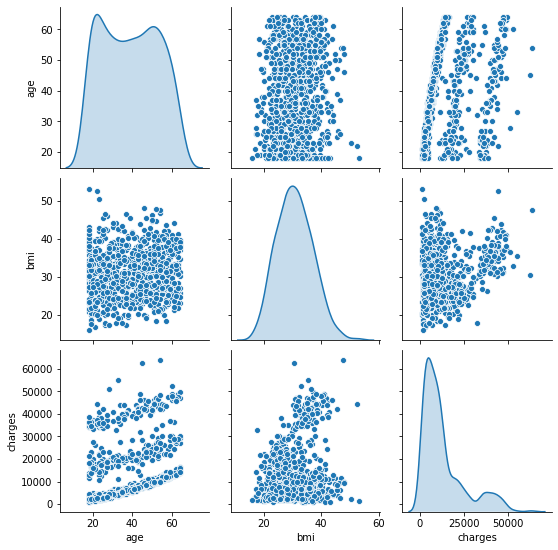

```python
# Create a new dataframe of only numeric variables and visualize with pairplot:

insurance_num=df_train[[ 'age', 'bmi', 'charges']]

sns.pairplot(insurance_num, diag_kind='kde')
plt.show()
```

It seems there are linear dependencies between age, bmi and charges

## Visualising Catagorical Variables

```python
df_train.info()
```

[output not shown]

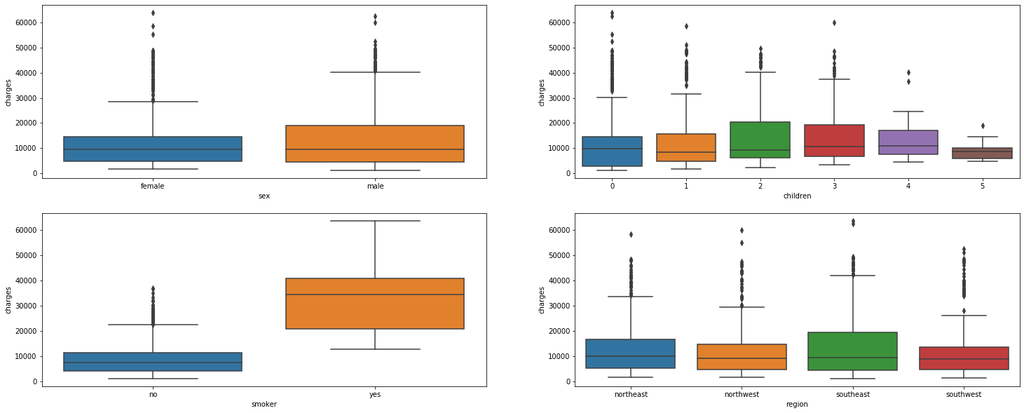

```python
# Build boxplot of all categorical variables (using original data) againt the target variable charges

plt.figure(figsize=(25, 10))
plt.subplot(2,2,1)
sns.boxplot(x = 'sex', y = 'charges', data = insurance)
plt.subplot(2,2,2)
sns.boxplot(x = 'children', y = 'charges', data = insurance)
plt.subplot(2,2,3)
sns.boxplot(x = 'smoker', y = 'charges', data = insurance)
plt.subplot(2,2,4)
sns.boxplot(x = 'region', y = 'charges', data = insurance)
plt.show()
```

Pre-dummification the data suggests:

## Correlation Matrix

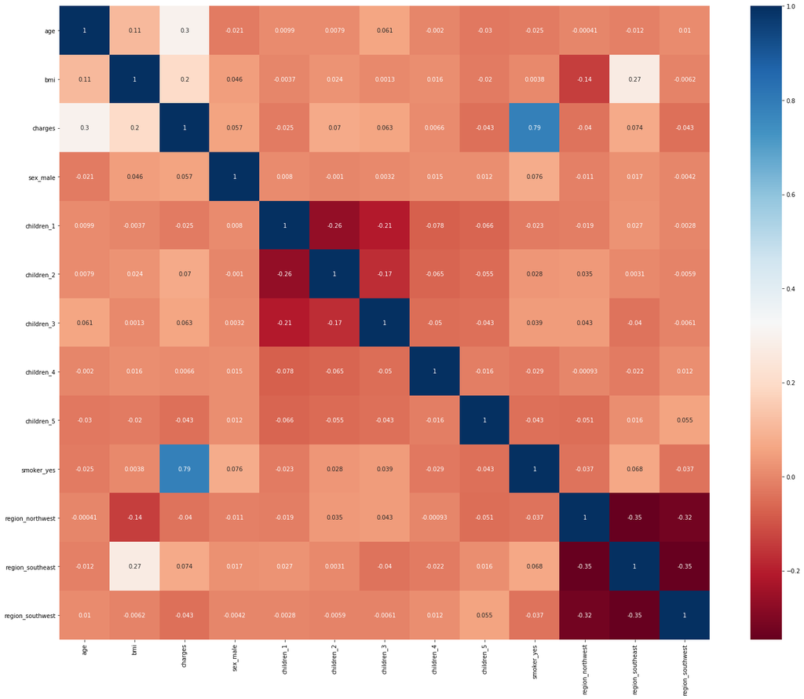

```python
# Let's check the correlation coefficients to see which variables are highly correlated. Note:
# here we are considering only those variables (dataframe: insurance_new) that were chosen for analysis

plt.figure(figsize = (25,20))
sns.heatmap(insurance_new.corr(), annot = True, cmap="RdBu")
plt.show()
```

High correlation between charges and being a smoker, lesser correlation between charges and bmi/age

# RESCALING THE FEATURES

```python
from sklearn.preprocessing import MinMaxScaler
```

```python
scaler= MinMaxScaler()
```

```python
df_train.head()
```

|  | age | bmi | charges | sex_male | children_1 | children_2 | children_3 | children_4 | children_5 | smoker_yes | region_northwest | region_southeast | region_southwest |
| --- | --- | --- | --- | --- | --- | --- | --- | --- | --- | --- | --- | --- | --- |
| 966 | 51 | 24.795 | 23967.38305 | 1 | 0 | 1 | 0 | 0 | 0 | 1 | 1 | 0 | 0 |
| 522 | 51 | 33.915 | 9866.30485 | 0 | 0 | 0 | 0 | 0 | 0 | 0 | 0 | 0 | 0 |
| 155 | 44 | 39.520 | 6948.70080 | 1 | 0 | 0 | 0 | 0 | 0 | 0 | 1 | 0 | 0 |
| 671 | 29 | 31.160 | 3943.59540 | 0 | 0 | 0 | 0 | 0 | 0 | 0 | 0 | 0 | 0 |
| 1173 | 38 | 29.260 | 6457.84340 | 1 | 0 | 1 | 0 | 0 | 0 | 0 | 1 | 0 | 0 |

```python
df_train.columns
```

```
Index(['age', 'bmi', 'charges', 'sex_male', 'children_1', 'children_2',
       'children_3', 'children_4', 'children_5', 'smoker_yes',
       'region_northwest', 'region_southeast', 'region_southwest'],
      dtype='object')
```

```python
# Apply scaler() to all the numeric variables

num_vars = ['age', 'bmi', 'charges']

df_train[num_vars] = scaler.fit_transform(df_train[num_vars])
```

```python
# Checking values after scaling
df_train.head()
```

|  | age | bmi | charges | sex_male | children_1 | children_2 | children_3 | children_4 | children_5 | smoker_yes | region_northwest | region_southeast | region_southwest |
| --- | --- | --- | --- | --- | --- | --- | --- | --- | --- | --- | --- | --- | --- |
| 966 | 0.717391 | 0.237692 | 0.364661 | 1 | 0 | 1 | 0 | 0 | 0 | 1 | 1 | 0 | 0 |
| 522 | 0.717391 | 0.483051 | 0.139579 | 0 | 0 | 0 | 0 | 0 | 0 | 0 | 0 | 0 | 0 |
| 155 | 0.565217 | 0.633844 | 0.093008 | 1 | 0 | 0 | 0 | 0 | 0 | 0 | 1 | 0 | 0 |
| 671 | 0.239130 | 0.408932 | 0.045040 | 0 | 0 | 0 | 0 | 0 | 0 | 0 | 0 | 0 | 0 |
| 1173 | 0.434783 | 0.357815 | 0.085173 | 1 | 0 | 1 | 0 | 0 | 0 | 0 | 1 | 0 | 0 |

```python
df_train.describe()
```

|  | age | bmi | charges | sex_male | children_1 | children_2 | children_3 | children_4 | children_5 | smoker_yes | region_northwest | region_southeast | region_southwest |
| --- | --- | --- | --- | --- | --- | --- | --- | --- | --- | --- | --- | --- | --- |
| count | 936.000000 | 936.000000 | 936.000000 | 936.000000 | 936.000000 | 936.000000 | 936.000000 | 936.000000 | 936.000000 | 936.000000 | 936.000000 | 936.000000 | 936.000000 |
| mean | 0.458171 | 0.399088 | 0.192301 | 0.497863 | 0.236111 | 0.184829 | 0.117521 | 0.021368 | 0.011752 | 0.194444 | 0.244658 | 0.282051 | 0.242521 |
| std | 0.306065 | 0.167115 | 0.193690 | 0.500263 | 0.424918 | 0.388366 | 0.322213 | 0.144683 | 0.107826 | 0.395984 | 0.430114 | 0.450239 | 0.428837 |
| min | 0.000000 | 0.000000 | 0.000000 | 0.000000 | 0.000000 | 0.000000 | 0.000000 | 0.000000 | 0.000000 | 0.000000 | 0.000000 | 0.000000 | 0.000000 |
| 25% | 0.173913 | 0.277441 | 0.055033 | 0.000000 | 0.000000 | 0.000000 | 0.000000 | 0.000000 | 0.000000 | 0.000000 | 0.000000 | 0.000000 | 0.000000 |
| 50% | 0.456522 | 0.391176 | 0.129662 | 0.000000 | 0.000000 | 0.000000 | 0.000000 | 0.000000 | 0.000000 | 0.000000 | 0.000000 | 0.000000 | 0.000000 |
| 75% | 0.717391 | 0.512039 | 0.245247 | 1.000000 | 0.000000 | 0.000000 | 0.000000 | 0.000000 | 0.000000 | 0.000000 | 0.000000 | 1.000000 | 0.000000 |
| max | 1.000000 | 1.000000 | 1.000000 | 1.000000 | 1.000000 | 1.000000 | 1.000000 | 1.000000 | 1.000000 | 1.000000 | 1.000000 | 1.000000 | 1.000000 |

# BUILDING A LINEAR MODEL

## Dividing into X and Y sets for the model building

```python
y_train = df_train.pop("charges")
X_train = df_train
```

```python
y_train.head()
```

```
966     0.364661
522     0.139579
155     0.093008
671     0.045040
1173    0.085173
Name: charges, dtype: float64
```

```python
X_train.head()
```

|  | age | bmi | sex_male | children_1 | children_2 | children_3 | children_4 | children_5 | smoker_yes | region_northwest | region_southeast | region_southwest |
| --- | --- | --- | --- | --- | --- | --- | --- | --- | --- | --- | --- | --- |
| 966 | 0.717391 | 0.237692 | 1 | 0 | 1 | 0 | 0 | 0 | 1 | 1 | 0 | 0 |
| 522 | 0.717391 | 0.483051 | 0 | 0 | 0 | 0 | 0 | 0 | 0 | 0 | 0 | 0 |
| 155 | 0.565217 | 0.633844 | 1 | 0 | 0 | 0 | 0 | 0 | 0 | 1 | 0 | 0 |
| 671 | 0.239130 | 0.408932 | 0 | 0 | 0 | 0 | 0 | 0 | 0 | 0 | 0 | 0 |
| 1173 | 0.434783 | 0.357815 | 1 | 0 | 1 | 0 | 0 | 0 | 0 | 1 | 0 | 0 |

### RFE

Recursive feature elimination: We will be using the **LinearRegression function from SciKit Learn** for its compatibility with RFE (which is a utility from sklearn)

```python
#Importing RFE and LinearRegression
from sklearn.feature_selection import RFE
from sklearn.linear_model import LinearRegression
```

```python
# Running RFE with the output number of the variable equal to 6
lm= LinearRegression()
lm.fit(X_train,y_train)
rfe= RFE(lm,6)
rfe=rfe.fit(X_train,y_train)
```

```python
list(zip(X_train.columns,rfe.support_,rfe.ranking_))
```

```
[('age', True, 1),
 ('bmi', True, 1),
 ('sex_male', False, 7),
 ('children_1', False, 6),
 ('children_2', True, 1),
 ('children_3', False, 2),
 ('children_4', True, 1),
 ('children_5', True, 1),
 ('smoker_yes', True, 1),
 ('region_northwest', False, 5),
 ('region_southeast', False, 4),
 ('region_southwest', False, 3)]
```

```python
col=X_train.columns[rfe.support_]
col
```

```
Index(['age', 'bmi', 'children_2', 'children_4', 'children_5', 'smoker_yes'], dtype='object')
```

```python
X_train.columns[~rfe.support_]
```

```
Index(['sex_male', 'children_1', 'children_3', 'region_northwest',
       'region_southeast', 'region_southwest'],
      dtype='object')
```

```python
# Creating X_test dataframe with RFE selected variables
X_train_rfe = X_train[col]
```

# Building Linear Model using 'STATS MODEL'

### VIF

```python
# Check for the VIF values of the feature variables.
from statsmodels.stats.outliers_influence import variance_inflation_factor

# Create a dataframe that will contain the names of all the feature variables and their respective VIFs
vif = pd.DataFrame()
vif['Features'] = X_train_rfe.columns
vif['VIF'] = [variance_inflation_factor(X_train_rfe.values, i) for i in range(X_train_rfe.shape[1])]
vif['VIF'] = round(vif['VIF'], 2)
vif = vif.sort_values(by = "VIF", ascending = False)
vif
```

|  | Features | VIF |
| --- | --- | --- |
| 1 | bmi | 2.98 |
| 0 | age | 2.72 |
| 2 | children_2 | 1.22 |
| 5 | smoker_yes | 1.21 |
| 3 | children_4 | 1.03 |
| 4 | children_5 | 1.01 |

No VIF value above 5 means no problematic multicollinearity

```python
import statsmodels.api as sm

# Add a constant
X_train_lm1 = sm.add_constant(X_train_rfe)

# Create fitted model
lr1 = sm.OLS(y_train, X_train_lm1).fit()
```

```python
# Print a summary of the linear regression model obtained
print(lr1.summary())
```

```
                            OLS Regression Results
==============================================================================
Dep. Variable:                charges   R-squared:                       0.737
Model:                            OLS   Adj. R-squared:                  0.735
Method:                 Least Squares   F-statistic:                     432.9
Date:                Sat, 15 Aug 2020   Prob (F-statistic):          4.75e-265
Time:                        21:07:37   Log-Likelihood:                 833.09
No. Observations:                 936   AIC:                            -1652.
Df Residuals:                     929   BIC:                            -1618.
Df Model:                           6
Covariance Type:            nonrobust
==============================================================================
                 coef    std err          t      P>|t|      [0.025      0.975]
------------------------------------------------------------------------------
const         -0.0410      0.010     -4.281      0.000      -0.060      -0.022
age            0.1916      0.011     17.828      0.000       0.170       0.213
bmi            0.1646      0.020      8.366      0.000       0.126       0.203
children_2     0.0232      0.008      2.750      0.006       0.007       0.040
children_4     0.0371      0.023      1.642      0.101      -0.007       0.081
children_5     0.0239      0.030      0.787      0.431      -0.036       0.084
smoker_yes     0.3829      0.008     46.383      0.000       0.367       0.399
==============================================================================
Omnibus:                      215.324   Durbin-Watson:                   2.026
Prob(Omnibus):                  0.000   Jarque-Bera (JB):              495.481
Skew:                           1.240   Prob(JB):                    2.56e-108
Kurtosis:                       5.560   Cond. No.                         11.3
==============================================================================

Warnings:
[1] Standard Errors assume that the covariance matrix of the errors is correctly specified.
```

# Final Model Interpretation

The model explains 73,7% of the variance on charges.

Age, BMI and Smoker have a significant positive influence on charges. The effect of smoker is by far the largest.

The prior elimination of the region variables and the insignificance of most children dummies suggests no notable effect of region and number of children on number of charges. Only 2 children is significant here on an alpha=5% level, which may be an isolated effect or a fluke in the data. By effect size it has minimal influence.

# Testing ASSUMPTIONS

## Error terms are normally distributed with mean zero (not X, Y)

- Residual Analysis Of Training Data

```python
y_train_pred = lr1.predict(X_train_lm1)
```

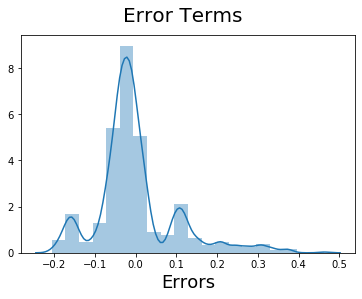

```python
res = y_train-y_train_pred
# Plot the histogram of the error terms
fig = plt.figure()
sns.distplot((res), bins = 20)
fig.suptitle('Error Terms', fontsize = 20)                  # Plot heading
plt.xlabel('Errors', fontsize = 18)
```

# Making predictions using the final model

### Applying the scaling on the test sets

```python
# Apply scaler() to all numeric variables in test dataset. Note: we will only use scaler.transform,
# as we want to use the metrics that the model learned from the training data to be applied on the test data.
# In other words, we want to prevent the information leak from train to test dataset.

num_vars = ['age', 'bmi', 'charges']

df_test[num_vars] = scaler.transform(df_test[num_vars])
```

```python
df_test.head()
```

|  | age | bmi | charges | sex_male | children_1 | children_2 | children_3 | children_4 | children_5 | smoker_yes | region_northwest | region_southeast | region_southwest |
| --- | --- | --- | --- | --- | --- | --- | --- | --- | --- | --- | --- | --- | --- |
| 12 | 0.108696 | 0.496099 | 0.011253 | 1 | 0 | 0 | 0 | 0 | 0 | 0 | 0 | 0 | 1 |
| 306 | 0.217391 | 0.310465 | 0.304170 | 0 | 0 | 1 | 0 | 0 | 0 | 0 | 0 | 0 | 1 |
| 318 | 0.565217 | 0.314366 | 0.100550 | 0 | 0 | 0 | 0 | 0 | 0 | 0 | 1 | 0 | 0 |
| 815 | 0.043478 | 0.417003 | 0.012068 | 0 | 0 | 0 | 0 | 0 | 0 | 0 | 0 | 1 | 0 |
| 157 | 0.000000 | 0.247915 | 0.229795 | 1 | 0 | 0 | 0 | 0 | 0 | 1 | 0 | 0 | 0 |

```python
df_test.describe()
```

|  | age | bmi | charges | sex_male | children_1 | children_2 | children_3 | children_4 | children_5 | smoker_yes | region_northwest | region_southeast | region_southwest |
| --- | --- | --- | --- | --- | --- | --- | --- | --- | --- | --- | --- | --- | --- |
| count | 402.000000 | 402.000000 | 402.000000 | 402.000000 | 402.000000 | 402.000000 | 402.000000 | 402.000000 | 402.000000 | 402.000000 | 402.000000 | 402.000000 | 402.000000 |
| mean | 0.467662 | 0.387383 | 0.197677 | 0.522388 | 0.256219 | 0.166667 | 0.116915 | 0.012438 | 0.017413 | 0.228856 | 0.238806 | 0.248756 | 0.243781 |
| std | 0.304236 | 0.156621 | 0.192579 | 0.500121 | 0.437088 | 0.373142 | 0.321720 | 0.110967 | 0.130967 | 0.420620 | 0.426885 | 0.432831 | 0.429897 |
| min | 0.000000 | 0.023002 | 0.000154 | 0.000000 | 0.000000 | 0.000000 | 0.000000 | 0.000000 | 0.000000 | 0.000000 | 0.000000 | 0.000000 | 0.000000 |
| 25% | 0.195652 | 0.278585 | 0.060686 | 0.000000 | 0.000000 | 0.000000 | 0.000000 | 0.000000 | 0.000000 | 0.000000 | 0.000000 | 0.000000 | 0.000000 |
| 50% | 0.478261 | 0.383105 | 0.138259 | 1.000000 | 0.000000 | 0.000000 | 0.000000 | 0.000000 | 0.000000 | 0.000000 | 0.000000 | 0.000000 | 0.000000 |
| 75% | 0.733696 | 0.483051 | 0.254641 | 1.000000 | 1.000000 | 0.000000 | 0.000000 | 0.000000 | 0.000000 | 0.000000 | 0.000000 | 0.000000 | 0.000000 |
| max | 1.000000 | 0.890503 | 0.940158 | 1.000000 | 1.000000 | 1.000000 | 1.000000 | 1.000000 | 1.000000 | 1.000000 | 1.000000 | 1.000000 | 1.000000 |

### Dividing into X_test and y_test

```python
y_test = df_test.pop('charges')
X_test = df_test
X_test.info()
```

```
<class 'pandas.core.frame.DataFrame'>
Int64Index: 402 entries, 12 to 1164
Data columns (total 12 columns):
 #   Column            Non-Null Count  Dtype
---  ------            --------------  -----
 0   age               402 non-null    float64
 1   bmi               402 non-null    float64
 2   sex_male          402 non-null    uint8
 3   children_1        402 non-null    uint8
 4   children_2        402 non-null    uint8
 5   children_3        402 non-null    uint8
 6   children_4        402 non-null    uint8
 7   children_5        402 non-null    uint8
 8   smoker_yes        402 non-null    uint8
 9   region_northwest  402 non-null    uint8
 10  region_southeast  402 non-null    uint8
 11  region_southwest  402 non-null    uint8
dtypes: float64(2), uint8(10)
memory usage: 13.3 KB
```

```python
#Selecting the variables that were part of final model.
col1=X_train_rfe.columns
X_test=X_test[col1]
# Adding constant variable to test dataframe
X_test_lm1 = sm.add_constant(X_test)
X_test_lm1.info()
```

```
<class 'pandas.core.frame.DataFrame'>
Int64Index: 402 entries, 12 to 1164
Data columns (total 7 columns):
 #   Column      Non-Null Count  Dtype
---  ------      --------------  -----
 0   const       402 non-null    float64
 1   age         402 non-null    float64
 2   bmi         402 non-null    float64
 3   children_2  402 non-null    uint8
 4   children_4  402 non-null    uint8
 5   children_5  402 non-null    uint8
 6   smoker_yes  402 non-null    uint8
dtypes: float64(3), uint8(4)
memory usage: 14.1 KB
```

```python
# Making predictions

y_pred = lr1.predict(X_test_lm1)
```

# MODEL EVALUATION

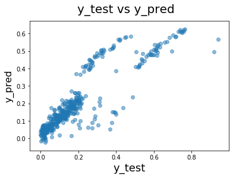

```python
# Plotting y_test and y_pred to understand the spread

fig = plt.figure()
plt.scatter(y_test, y_pred, alpha=.5)
fig.suptitle('y_test vs y_pred', fontsize = 20)              # Plot heading
plt.xlabel('y_test', fontsize = 18)                          # X-label
plt.ylabel('y_pred', fontsize = 16)
plt.show()
```